# Vol Historica e Implicita

Jose Pablo Vazquez

4/5/2021

Conocimiento de clase que describe lo aprendido

**Vol implicita :** es una proyección de la magnitud de un movimiento anticipado del mercado, independientemente de la dirección. En otras palabras, la volatilidad implícita refleja el rango y la incertidumbre sobre cuán alto o bajo podría subir o bajar la cotización de un activo subyacente. ¿Como se diferencia de la vol historica? La volatilidad histórica es la volatilidad basada en el precio histórico del subyacente. Tiene en cuenta lo que ha ocurrido en el pasado. Mientras que la volatilidad implícita está basada en el precio de las opciones, y tiene en cuenta lo que puede ocurrir en el futuro.

CONSIDEREMOS LA SIGUIENTE INFORMACION SOBRE EL PRECIO LAS CARACTERISTICAS DE UNA OPCION

TIPO: CALL PRECIO : 7.15 SUBYACENTE : 14.18 VENCIMIENTO : 9 meses (timepo esta anual) t = 3/4 Tasa de interes : 4.4 % (lo que serian los cetes)

S = last izquierda arriba 14.18 k = Strike r = cetes 4.4 % tt = tiempo 3/4 (9 meses) d = dividendos 0

Precio = last call fecha de vencimiento de diciembre ¿Que valor sigma, hace posible en el modelo de BS que 7.15 sea el precio de una call con las caracteristicas señaladas?

Para buscar la volatilidad implicita hacemos lo siguiente:

1. Usar las imagenes proporcionadas y sacar la volatilidad implicita para todas las opciones CALL

Construir una tabla como esta

K V_IMP 8 0.7883 8.5 9 9.5

```
## # A tibble: 7 x 2
##       k Vol_implicita
##   <dbl>         <dbl>
## 1   8           0.788
## 2   8.5         0.747
## 3   9           0.710
## 4   9.5         0.677
## 5  12           0.563
## 6  15.5         0.497
## 7  16.5         0.491
```

2. Graficar k contra la vol_implicita

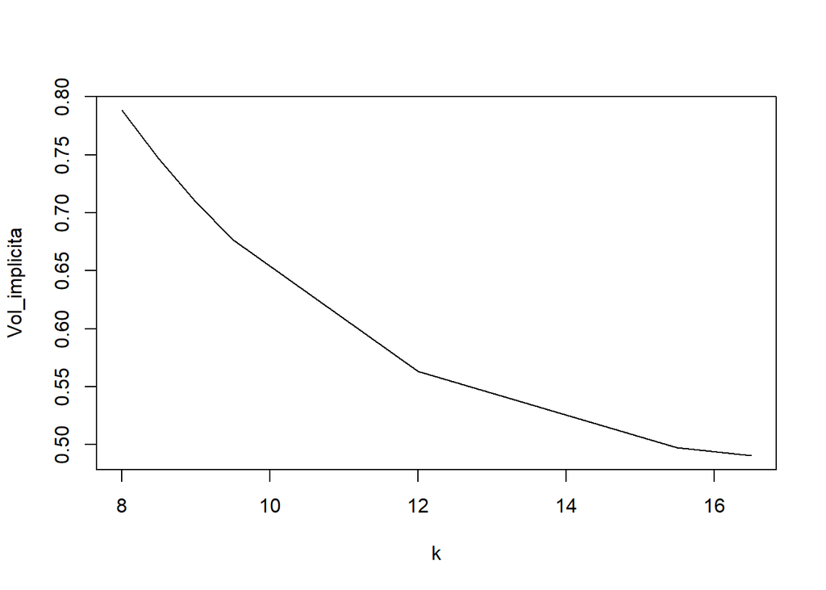

3. Investigar que es la sonrisa de volatilidad